# 全等的應用、證明與作圖連結

> 來源整理：改國二下6_三角形的全等_易讀版.md

## SSS 與 SAS 的尺規作圖

> 學習目標：全等作圖能看出為什麼某些條件會把三角形固定住。

### 先抓住核心

- SSS 作圖：先作底邊，再以兩端點為圓心畫兩個圓弧，交點決定第三頂點。
- 只要三邊固定，第三頂點的位置只剩上下鏡射，不影響全等。
- SAS 作圖：先作已知角，再在角的兩邊取兩段已知長度。
- 夾角固定後，兩邊端點一連起來，三角形就被決定。
- 作圖過程可視為全等判定的視覺證明。

### 解題流程

1. SSS：作 AB = x。
2. SSS：以 A 為圓心、y 為半徑畫弧；以 B 為圓心、z 為半徑畫弧。
3. SSS：兩弧交於 C，連 AC、BC。
4. SAS：先作角 A。
5. SAS：在角兩邊取 AB=a、AC=b，再連 BC。

### 公式、性質與判斷

- **SSS 作圖**：底邊 + 兩圓弧交點。
- **SAS 作圖**：先作夾角，再取兩邊長。

### 例題拆解

- 以 AB 為底，AC 與 BC 長度固定時，C 只能在兩弧交點上。
- 已知 ∠A 與 AB、AC，點 B、C 都固定在角的兩邊上，因此三角形固定。

### 易錯提醒

- SSS 作圖半徑拿錯，第三點位置就錯。
- SAS 先取邊長卻沒有固定夾角，圖形不唯一。

### 小練一下

- SSS 作圖中，第三點 C 由什麼決定？
- SAS 作圖為什麼要先作夾角？

### 記憶鉤子

- SSS 是兩個圓弧交點；SAS 是角兩邊各取一段。
- 上下鏡射的三角形仍然全等。

### 圖像化理解

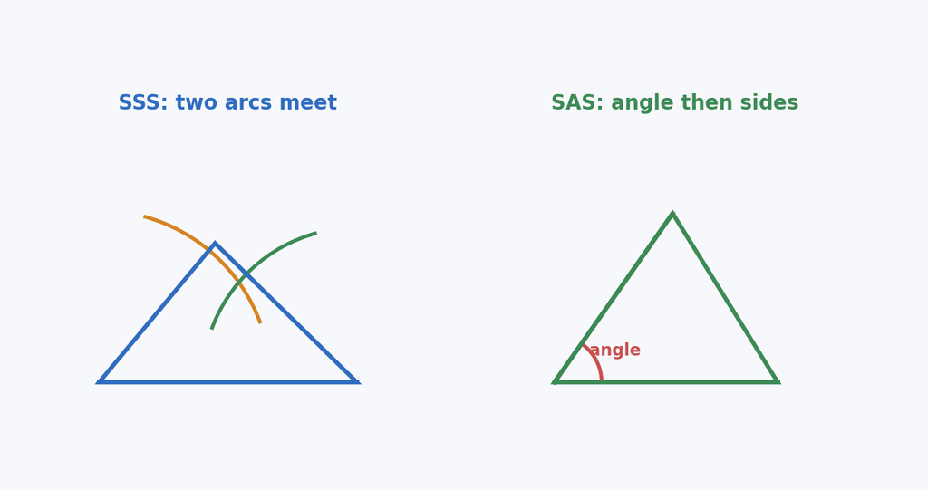

SSS 與 SAS 的尺規作圖

圖解：用圓弧交點和角兩邊取長示意 SSS/SAS 作圖。

## ASA 與 AAS 的尺規作圖

> 學習目標：兩角加一邊的作圖，關鍵在先固定一條邊，再讓兩條射線交出第三頂點。

### 先抓住核心

- ASA 作圖：先作夾邊，再在兩端作已知角，兩射線交點就是第三頂點。
- AAS 作圖：先用三角形內角和補出第三角，再轉成 ASA 作圖。
- 兩條射線的交點固定時，三角形也被固定。
- AAS 的已知邊不一定在兩角中間，所以常先求第三角。
- 這也說明為什麼兩角和一邊足以判定全等。

### 解題流程

1. ASA：作 AB = a。
2. ASA：在 A 作 ∠A，在 B 作 ∠B。
3. ASA：兩射線交於 C。
4. AAS：先作第三角 = 180° - ∠1 - ∠2。
5. AAS：再選擇合適邊，照 ASA 流程完成。

### 公式、性質與判斷

- **ASA 作圖**：夾邊 + 兩端角。
- **AAS 作圖**：先補第三角，再作 ASA。
- **第三角**：180° - 已知兩角。

### 例題拆解

- 已知 AB 與 ∠A、∠B，兩條角射線交點 C 唯一，所以三角形固定。
- AAS 若已知兩角與非夾邊，可先求出第三角，把它轉成兩角夾邊的情境。

### 易錯提醒

- 兩端角畫在不同側，導致三角形位置錯誤。
- AAS 忘記先用 180° 補第三角。

### 小練一下

- ASA 作圖第三頂點由什麼決定？
- AAS 作圖常先補哪一個角？

### 記憶鉤子

- 兩角一邊作圖的核心：兩條射線交出第三點。
- AAS 不神秘，常常是補角後變成 ASA。

### 圖像化理解

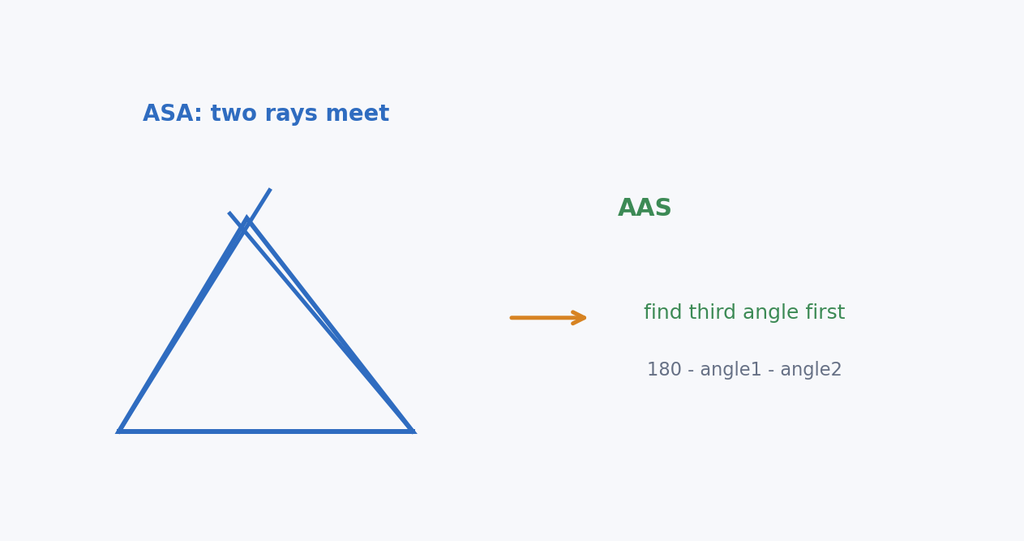

ASA 與 AAS 的尺規作圖

圖解：示意 ASA 以夾邊兩端作角，AAS 先補第三角。

## 用對應邊角解 x、y 與周長

> 學習目標：全等應用的第一類題型，是把對應邊角相等改寫成方程式。

### 先抓住核心

- 若兩三角形全等，對應邊相等、對應角相等。
- 含 x、y 的角度題常先用內角和建立方程。
- 含 x、y 的邊長題常用對應邊相等建立聯立方程。
- 周長相等，所以可用其中一個三角形的邊長總和求另一個。
- 所有代數式都要先確認對應關係再列式。

### 解題流程

1. 先由全等式列出對應表。
2. 角度含未知數時，使用對應角相等或內角和。
3. 邊長含未知數時，使用對應邊相等。
4. 解出未知數後，再求周長或目標邊。

### 公式、性質與判斷

- **對應角**：相等，可列角度方程。
- **對應邊**：相等，可列邊長方程。
- **周長**：全等三角形周長相等。

### 例題拆解

- 若 ∠B=2x-10、∠D=x+15、∠C=70，且 A 對 D，可用 (x+15)+(2x-10)+70=180 得 x=35。
- 若 BC=y+3、EF=3y-1 且 BC 對 EF，則 y+3=3y-1，得 y=2。
- 若三邊為 7、6、5，周長是 18。

### 易錯提醒

- 對應邊看錯，方程式整組錯掉。
- 解出未知數後忘記回代求目標邊或周長。

### 小練一下

- 若 AB=5x、DE=4y 且 AB 對 DE，可列什麼式子？
- 全等三角形的周長一定相等嗎？

### 記憶鉤子

- 全等代數題的順序：對應表、列式、解未知、回代。
- 不要先解 x，先找誰對誰。

### 圖像化理解

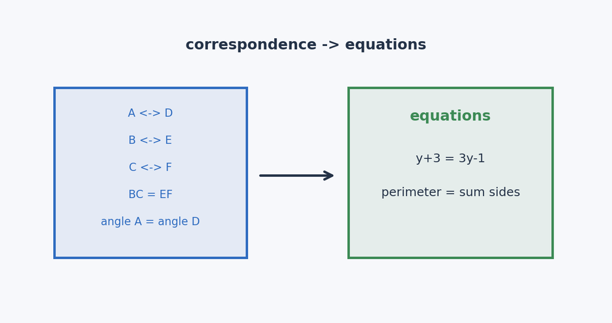

用對應邊角解 x、y 與周長

圖解：用對應表把邊角相等轉成 x、y 方程式。

## 全等證明流程：找條件、排順序、寫結論

> 學習目標：證明全等不是只寫一個判定名稱，而是要把三個必要條件列清楚。

### 先抓住核心

- 先圈出要證明全等的兩個三角形。
- 找共用邊、正方形邊、正三角形邊、折疊重合邊等相等來源。
- 找直角、對頂角、平行線角、折疊角、正圖形角等相等來源。
- 把條件排成 SSS、SAS、ASA、AAS 或 RHS 的順序。
- 證明完全等後，才能使用對應邊角相等。

### 解題流程

1. 寫出目標：要證明哪兩個三角形全等。
2. 列出邊相等條件。
3. 列出角相等條件。
4. 判斷符合哪一個全等判定。
5. 寫出全等結論，再推出對應邊角。

### 公式、性質與判斷

- **證明格式**：條件1、條件2、條件3 -> 判定 -> 全等。
- **常見來源**：共用邊、正方形、正三角形、折疊、對頂角、平行線。

### 例題拆解

- 兩個正方形提供邊相等與直角，因此常能湊出 SAS。
- 摺疊提供重合線段與重合角，因此常能湊出 ASA 或 SAS。
- 證明 △BCG ≅ △DCE 後，才能推出 ∠CBG = ∠CDE。

### 易錯提醒

- 只寫『所以全等』，沒有列出判定所需條件。
- 還沒證明全等，就先使用對應邊角相等。

### 小練一下

- 證明全等前，可以直接說對應角相等嗎？
- 正方形題常提供哪些全等條件？

### 記憶鉤子

- 證明全等像寫收據：每個條件都要有來源。
- 先全等，後對應；順序不能倒。

### 圖像化理解

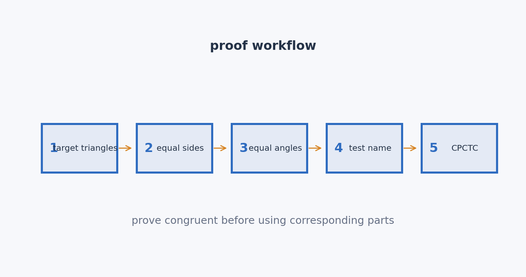

全等證明流程：找條件、排順序、寫結論

圖解：用流程圖示意全等證明的標準順序。

## 正方形與正三角形中的全等

> 學習目標：正方形和正三角形會自動提供大量相等邊角，是全等題最常見的條件來源。

### 先抓住核心

- 正方形四邊相等、四角都是 90°。
- 正三角形三邊相等、三角都是 60°。
- 兩個正方形共用或相接時，常能找到相等邊與相等夾角。
- 正三角形搭配已知邊相等時，常能用 SAS 證明兩個三角形全等。
- 證明全等後，可用對應角相等求角度。

### 解題流程

1. 標出正方形或正三角形提供的固定邊角。
2. 找出題目額外給的相等邊。
3. 檢查是否形成 SAS。
4. 證明全等後，轉換目標角或邊。

### 公式、性質與判斷

- **正方形**：邊相等，角 90°。
- **正三角形**：邊相等，角 60°。
- **常用判定**：多為 SAS。

### 例題拆解

- 若 ABC 是正三角形，AB=BC 且 ∠ABD=∠BCE=60° 加上 BD=CE，可用 SAS。
- 若兩個正方形共用頂點，可用正方形邊相等與 90° 組出 SAS。
- 若 △ABP ≅ △CBQ，且 ∠APB=98°，可推出對應角 ∠BQC=98°。

### 易錯提醒

- 忘記正三角形不只角相等，邊也相等。
- 只看圖形像正方形，但沒有題目條件就直接使用正方形性質。

### 小練一下

- 正三角形每個角是多少？
- 正方形題最常提供哪兩種條件？

### 記憶鉤子

- 正圖形題先把 60°、90° 和相等邊全部標上。
- 標完固定條件，全等判定通常會自己浮出來。

### 圖像化理解

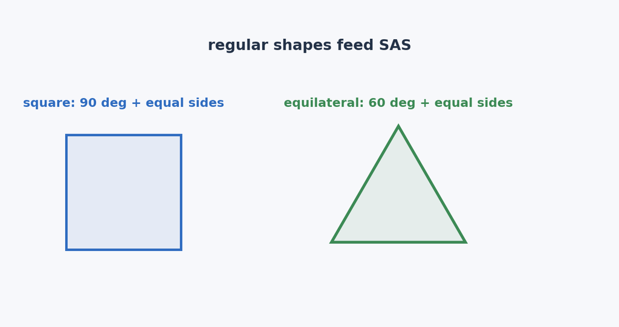

正方形與正三角形中的全等

圖解：示意正方形與正三角形如何提供 SAS 條件。

## 摺疊題中的全等與重合

> 學習目標：摺疊會讓重合的點、邊、角相等，這些都是證明全等的材料。

### 先抓住核心

- 摺疊後重合的點對應到同一位置，因此相關線段相等。
- 摺線常是對稱軸，摺線兩側的圖形常全等。
- 摺疊可提供角相等，也可提供邊相等。
- 長方形摺疊題常同時用直角、等邊、折疊角來湊 ASA 或 SAS。
- 若摺疊後出現直角三角形，可能還會搭配畢氏定理求長度或面積。

### 解題流程

1. 先標出摺疊前後重合的點。
2. 寫出重合邊相等、重合角相等。
3. 找直角或共用邊補足全等條件。
4. 證明全等後，再求長度、周長、面積。

### 易錯提醒

- 只看摺後圖，忘記標出原本和摺後的對應點。
- 還沒建立全等就直接使用某兩段相等。

### 小練一下

- 摺疊後重合的線段有什麼關係？
- 摺疊題中摺線常扮演什麼角色？

### 記憶鉤子

- 摺疊就是把一邊翻到另一邊，重合的東西就相等。
- 先找重合，再找全等，再算長度。

### 圖像化理解

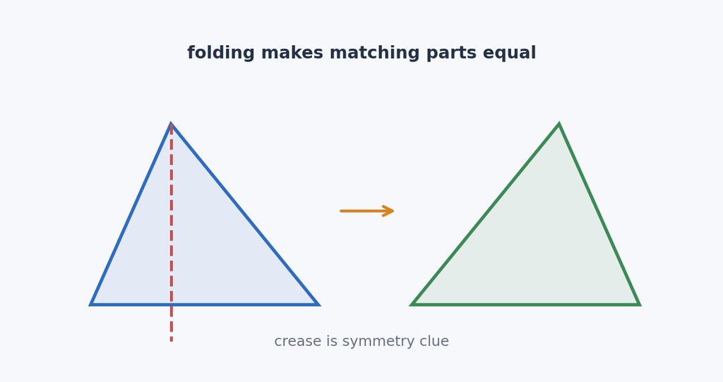

摺疊題中的全等與重合

圖解：示意摺線兩側圖形重合，轉成全等條件。

## 全等後接畢氏定理與面積

> 學習目標：有些題目先用全等得到等長，再用直角三角形的畢氏定理求高或面積。

### 解題流程

1. 先用全等或摺疊得到相等線段。
2. 找出直角三角形。
3. 用畢氏定理求未知邊。
4. 再代入面積或周長公式。

### 公式、性質與判斷

- **畢氏定理**：a^2 + b^2 = c^2。
- **三角形面積**：Area = base*height/2。
- **常見高**：sqrt(15^2 - 9^2)=12。

### 易錯提醒

- 把斜邊和直角邊放錯，畢氏式列反。
- 求到高後忘記面積要除以 2。

### 小練一下

- 腰長 13、底邊 10 的等腰三角形，高是多少？
- 底 18、高 12 的三角形面積是多少？

### 記憶鉤子

- 全等給等長，畢氏給未知邊，面積公式收尾。
- 看到摺疊加直角，通常有一段會用畢氏。

### 圖像化理解

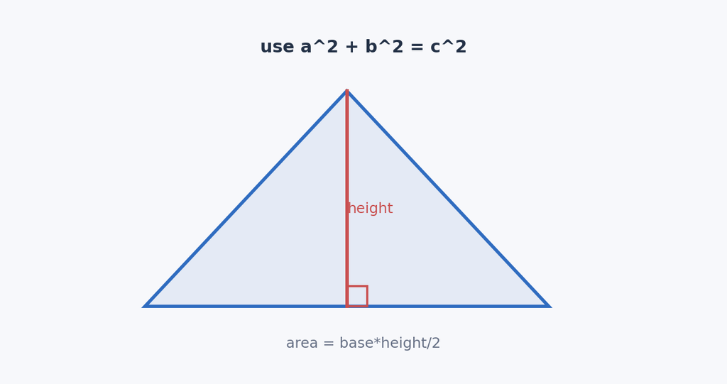

全等後接畢氏定理與面積

圖解：用等腰三角形高示意全等/對稱後接畢氏定理求面積。

## 全等、同高與面積比

> 學習目標：全等可幫你轉換邊長或角度，但面積比常要再看同底、同高或正三角形高的比例。

### 先抓住核心

- 全等三角形面積相等。
- 同高三角形的面積比等於底邊比。
- 同底三角形的面積比等於高的比。
- 正三角形邊長為 s 時，高與 s 成正比，所以同形正三角形面積可由邊或高比較。
- 複合圖形面積比題要先拆成幾個可比較的三角形。

### 解題流程

1. 先判斷哪些三角形全等，面積可直接相等。
2. 再看剩下三角形是否同高或同底。
3. 用底比或高比求面積比。
4. 必要時把正三角形的高寫成邊長乘固定比例。

### 公式、性質與判斷

- **同高面積比**：面積比 = 底邊比。
- **同底面積比**：面積比 = 高比。
- **正三角形高**：高 = 邊長*sqrt(3)/2。

### 例題拆解

- 若兩三角形同底，且高比為 2:6，面積比也是 1:3。
- 若兩三角形同高，且底比為 4:2，面積比是 2:1。
- 原講義中的正三角形組合可得到面積比 2:6:1。

### 易錯提醒

- 把邊長比直接當任意三角形面積比，沒有確認同高或同底。
- 全等只用來轉角度，忘記也可推出面積相等。

### 小練一下

- 同高三角形的面積比看哪一個量？
- 同底三角形的面積比看哪一個量？

### 記憶鉤子

- 面積比先問同底還是同高，再決定看高或底。
- 全等是面積相等，面積比題常還要多一步比較。

### 圖像化理解

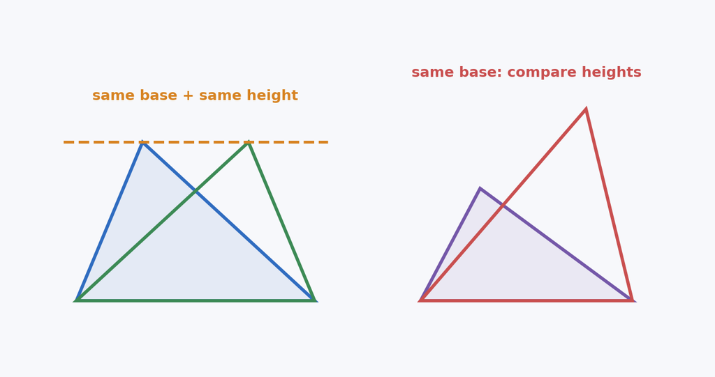

全等、同高與面積比

圖解：用同高與同底兩組三角形示意面積比判斷。

## 旋轉正方形與全等綜合策略

> 學習目標：旋轉或相交正方形題通常先找周角、直角與全等，再求目標角。

### 先抓住核心

- 兩個全等正方形提供相等邊與 90° 角。
- 相交角給出一個角時，常先用平角或周角求出相鄰角。
- 四邊形內角和 360° 可用來處理旋轉正方形形成的中間角。
- 證明某些角相等後，可推出目標角。
- 綜合題最後要回到三大工具：對應、全等判定、角度總和。

### 解題流程

1. 先標出兩個正方形的直角與等邊。
2. 由交角求相鄰角，例如 180° - 70° = 110°。
3. 用四邊形或周角扣掉已知角。
4. 再求目標角，如 90° - 已知角。

### 公式、性質與判斷

- **平角**：180°。
- **四邊形內角和**：360°。
- **正方形**：每角 90°。

### 例題拆解

- 若 ∠PEC=70°，則相鄰角 ∠PED=110°。
- 若四邊形中另外兩角都是 90°，則剩下角可由 360° - 90° - 90° - 110° = 70° 求得。
- 若正方形角為 90°，則另一部分角為 90° - 70° = 20°。

### 易錯提醒

- 把相鄰平角誤算成 70°，忘記要用 180° 扣。
- 只看旋轉後形狀，沒有標出原本正方形的對應角。

### 小練一下

- 正方形每個內角是多少？
- 與 70° 相鄰成平角的角是多少？

### 記憶鉤子

- 旋轉正方形題先找 90° 和 180°，再處理全等或對應。
- 綜合題不要急，從固定角和固定邊開始標。

### 圖像化理解

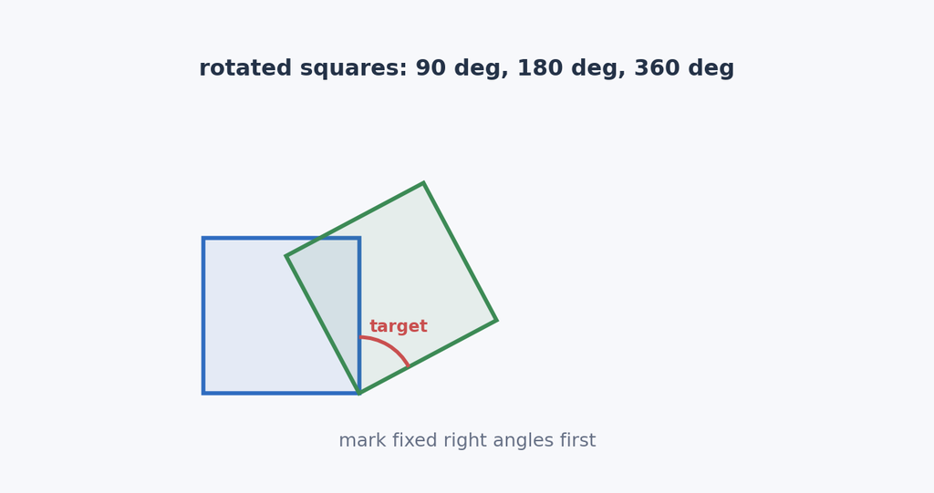

旋轉正方形與全等綜合策略

圖解：用兩個旋轉正方形示意平角、直角與目標角的關係。